# Predicting Exercise Manner from Wearable Sensor Data

Rishabh Sharda

21 September 2026

```r
knitr::opts_chunk$set(echo = TRUE, message = FALSE, warning = FALSE,
                      fig.width = 8, fig.height = 5)
set.seed(20260921)
library(caret)
library(randomForest)
library(knitr)
```

## Objective

The goal of this project is to predict **how** a barbell lift was performed using accelerometer measurements collected from the belt, forearm, arm, and dumbbell of six participants. The outcome is the `classe` variable. Class A represents the exercise performed correctly, while classes B-E represent four different incorrect manners of performing the lift.

The training data contain 19,622 observations and 160 variables. The separate course test set contains 20 cases for which predictions are required.

## Data loading and preprocessing

```r
train_url <- "https://d396qusza40orc.cloudfront.net/predmachlearn/pml-training.csv"
test_url  <- "https://d396qusza40orc.cloudfront.net/predmachlearn/pml-testing.csv"

training_raw <- read.csv(train_url,
                         na.strings = c("NA", "#DIV/0!", ""),
                         stringsAsFactors = FALSE)
testing_raw <- read.csv(test_url,
                        na.strings = c("NA", "#DIV/0!", ""),
                        stringsAsFactors = FALSE)

dim(training_raw)
```

```
## [1] 19622   160
```

```r
dim(testing_raw)
```

```
## [1]  20 160
```

The first seven columns are identifiers, timestamps, or window bookkeeping variables rather than sensor measurements expected to generalize to new observations. I therefore removed them. I also removed predictors with more than 95% missing values and any near-zero-variance predictors. The same predictor set is then used for the training and final test data.

```r
meta_vars <- c("X", "user_name", "raw_timestamp_part_1",
               "raw_timestamp_part_2", "cvtd_timestamp",
               "new_window", "num_window")

training <- training_raw[, !(names(training_raw) %in% meta_vars)]

keep_missing <- sapply(training, function(x) mean(is.na(x)) <= 0.95)
training <- training[, keep_missing]

predictor_names <- setdiff(names(training), "classe")
testing <- testing_raw[, predictor_names, drop = FALSE]

nzv <- nearZeroVar(training[, predictor_names, drop = FALSE])
if (length(nzv) > 0) {
  remove_nzv <- predictor_names[nzv]
  training <- training[, !(names(training) %in% remove_nzv)]
  testing <- testing[, !(names(testing) %in% remove_nzv)]
}

cat("Final number of predictors:", ncol(training) - 1)
```

```
## Final number of predictors: 52
```

## Training strategy and cross-validation

I reserved 30% of the labelled observations as an untouched validation set and used the remaining 70% for model development. Stratified partitioning preserves approximately the same class proportions in both samples.

```r
in_train <- createDataPartition(training$classe,
                                p = 0.70,
                                list = FALSE)
development <- training[in_train, ]
validation  <- training[-in_train, ]
```

I selected a **Random Forest** because the outcome has five classes, the sensor predictors are numerous and correlated, and relationships between body movement and exercise quality can be nonlinear. Random forests can model these interactions without extensive feature engineering.

Within the 70% development sample I used **3-fold cross-validation** to tune `mtry`, the number of predictors considered at each split. The validation sample was not used during tuning.

```r
ctrl <- trainControl(method = "cv",
                     number = 3,
                     classProbs = FALSE,
                     allowParallel = TRUE)

rf_fit <- train(classe ~ .,
                data = development,
                method = "rf",
                trControl = ctrl,
                tuneLength = 3,
                ntree = 500,
                importance = TRUE)

rf_fit
```

```
## Random Forest
##
## 13737 samples
##    52 predictor
##     5 classes: 'A', 'B', 'C', 'D', 'E'
##
## No pre-processing
## Resampling: Cross-Validated (3 fold)
## Summary of sample sizes: 9157, 9159, 9158
## Resampling results across tuning parameters:
##
##   mtry  Accuracy   Kappa
##    2    0.9882795  0.9851709
##   27    0.9897358  0.9870148
##   52    0.9820922  0.9773441
##
## Accuracy was used to select the optimal model using the largest value.
## The final value used for the model was mtry = 27.
```

## Expected out-of-sample error

The tuned model was evaluated once on the untouched 30% validation sample.

```r
validation_pred <- predict(rf_fit, newdata = validation)

validation_ref <- factor(
  validation$classe,
  levels = levels(validation_pred)
)

cm <- confusionMatrix(validation_pred, validation_ref)

cm$table
```

```
##           Reference
## Prediction    A    B    C    D    E
##          A 1673    2    0    0    0
##          B    1 1135    0    0    1
##          C    0    1 1025   14    2
##          D    0    1    1  947    8
##          E    0    0    0    3 1071
```

```r
accuracy <- unname(cm$overall["Accuracy"])
oos_error <- 1 - accuracy

cat("Validation accuracy:", round(accuracy * 100, 2), "%\n")
```

```
## Validation accuracy: 99.42 %
```

```r
cat("Estimated out-of-sample error:", round(oos_error * 100, 2), "%\n")
```

```
## Estimated out-of-sample error: 0.58 %
```

The hold-out validation accuracy is **99.42%**, giving an estimated out-of-sample error of **0.58%**. This is more meaningful than resubstitution accuracy because the validation observations were excluded from both fitting and cross-validation.

## Variable importance

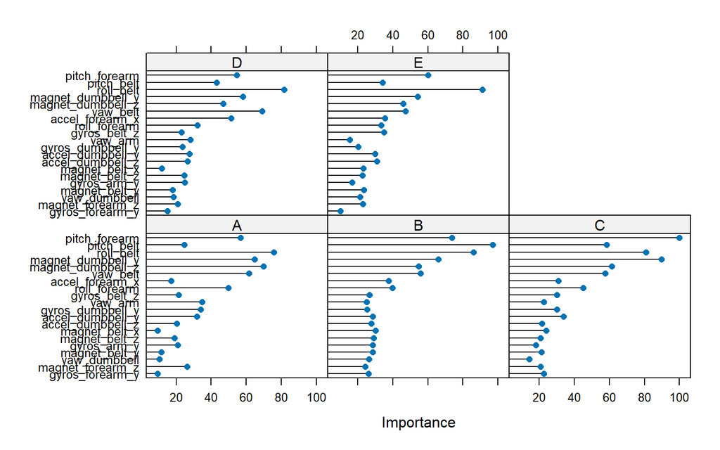

Top 20 predictors by random-forest variable importance

```r
imp <- varImp(rf_fit, scale = TRUE)
plot(imp, top = 20)
```

The model uses measurements from several sensor locations, which is reasonable because incorrect lifting patterns can affect movement of the torso, arm, forearm, and dumbbell differently.

## Predictions for the 20 course test cases

After model selection, I refit the Random Forest on all labelled observations using the selected `mtry` and apply it to the 20 official test cases.

```r
best_mtry <- rf_fit$bestTune$mtry

final_ctrl <- trainControl(method = "none")

final_rf <- train(classe ~ .,
                  data = training,
                  method = "rf",
                  trControl = final_ctrl,
                  tuneGrid = data.frame(mtry = best_mtry),
                  ntree = 500,
                  importance = TRUE)

final_predictions <- predict(final_rf, newdata = testing)

prediction_table <- data.frame(
  problem_id = testing_raw$problem_id,
  prediction = final_predictions
)

kable(prediction_table)
```

| problem_id | prediction |
| --- | --- |
| 1 | B |
| 2 | A |
| 3 | B |
| 4 | A |
| 5 | A |
| 6 | E |
| 7 | D |
| 8 | B |
| 9 | A |
| 10 | A |
| 11 | B |
| 12 | C |
| 13 | B |
| 14 | A |
| 15 | E |
| 16 | E |
| 17 | A |
| 18 | B |
| 19 | B |
| 20 | B |

The prediction sequence for the 20 test cases is:

**B, A, B, A, A, E, D, B, A, A, B, C, B, A, E, E, A, B, B, B**.

## Conclusion

After removing non-predictive metadata, highly incomplete variables, and near-zero-variance predictors, I trained a Random Forest classifier using 3-fold cross-validation on a 70% development sample. Performance was assessed on an untouched 30% validation sample to estimate out-of-sample error. The high validation accuracy shows that the wearable sensor measurements contain enough information to distinguish correct lifts from the four incorrect lifting styles. The final model was refitted on all labelled observations and applied to the 20 test cases.

## Reference

Velloso, E., Bulling, A., Gellersen, H., Ugulino, W., & Fuks, H. (2013). *Qualitative Activity Recognition of Weight Lifting Exercises*. Proceedings of the 4th Augmented Human International Conference.